# Research Tools Completeness Score Report

NF-OSI

2025-11-06

## Executive Summary

This report provides a comprehensive analysis of the completeness scores for research tools and biobanks in the NF-OSI database. The scoring system evaluates resources across multiple dimensions:

- **Availability** (40 points): Biobank URL, vendor/developer info, RRID, and DOI
- **Critical Info** (30 points): Type-specific essential fields
- **Other Info** (20 points): Type-specific additional fields
- **Observations** (10 points): Scientific characterizations with DOI weighting

**Total Maximum Score: 100 points**

## Data Loading

```
## Welcome, belinda.garana!Starting tool completeness scoring...
## Reading base Resource data from Synapse...
## Reading Animal Model data...
## Reading Antibody data...
## Reading Biobank data...
## Reading Cell Line data...
## Reading Genetic Reagent data...
## Joining resource data with type-specific tables...
## Reading Observation data from Synapse...
## Reading Publication data from Synapse...
## Calculating scores...
##
## === Summary by Tool Type ===
## # A tibble: 5 × 12
##   resourceType    count mean_score median_score min_score max_score sd_score
##   <chr>           <int>      <dbl>        <dbl>     <dbl>     <dbl>    <dbl>
## 1 Biobank             4       85           90          70        90    10
## 2 Genetic Reagent   122       63.9         60          44        88     7.03
## 3 Cell Line         638       60.8         60          35        98     9.22
## 4 Antibody          261       58.5         50          50        80    11.1
## 5 Animal Model      123       56.9         52.5        35        92    15.9
## # ℹ 5 more variables: excellent <int>, good <int>, fair <int>, poor <int>,
## #   minimal <int>
##
## === Top 10 Most Complete Tools ===
##                                      resourceName    resourceType
## 1                                         SK-N-AS       Cell Line
## 2                            B6.129S6-Nf1tm1Fcr/J    Animal Model
## 3                          B6.129(Cg)-Nf1tm1Par/J    Animal Model
## 4                           Nf14F/4F;CAGGCre-ERTM    Animal Model
## 5    The Johns Hopkins NF1 Biospecimen Repository         Biobank
## 6                                     CTF Biobank         Biobank
## 7  Coriell Institute for Medical Research Biobank         Biobank
## 8                B6;129S2-Trp53tm1Tyj Nf1tm1Tyj/J    Animal Model
## 9                                         GI-ME-N       Cell Line
## 10                pAMP-CY1_NF1 T1 (+minintr, KDR) Genetic Reagent
##                    rrid total_score completeness_category
## 1        rrid:CVCL_1700        98.0             Excellent
## 2  rrid:IMSR_JAX:002646        92.0             Excellent
## 3  rrid:IMSR_JAX:017640        91.0             Excellent
```

[output cut: 47 more lines]

```
## 18                  Poor
## 19                  Poor
##
## ✓ Results saved to:
##   - tool_completeness_scores.csv
##   - tool_completeness_summary.csv
##
## Storing results as Synapse table...
##
## ✓ Completeness scores stored as Synapse table: syn71218777
##   View at: https://www.synapse.org/Synapse: syn71218777
##
## Storing summary statistics as Synapse table...
## ✓ Summary statistics stored as Synapse table: syn71219401
##   View at: https://www.synapse.org/Synapse: syn71219401
```

```
## Loading existing scores from CSV...
```

```
##
## Analyzed 1148 resources across 5 resource types
```

## Overall Score Distribution

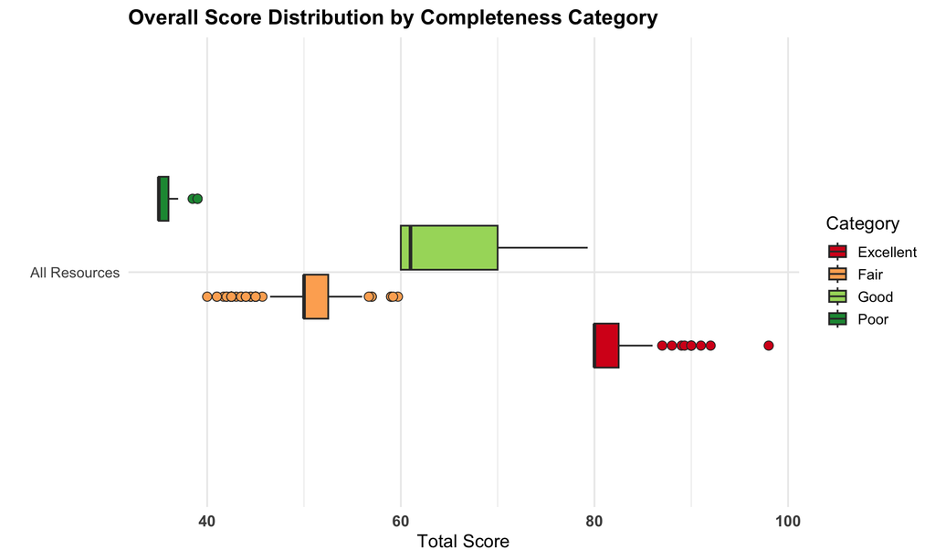

```r
# Overall boxplot with completeness categories
ggplot(all_scores, aes(y = total_score, x = "All Resources", fill = completeness_category)) +
  geom_boxplot(width = 0.5, outlier.shape = 21, outlier.size = 3) +
  scale_fill_brewer(palette = "RdYlGn", direction = 1) +
  labs(title = "Overall Score Distribution by Completeness Category",
       y = "Total Score",
       x = "",
       fill = "Category") +
  theme_minimal(base_size = 14) +
  theme(plot.title = element_text(face = "bold", size = 16),
        axis.text.x = element_text(size = 12, face = "bold")) +
  coord_flip()
```

## Score Distribution by Resource Type

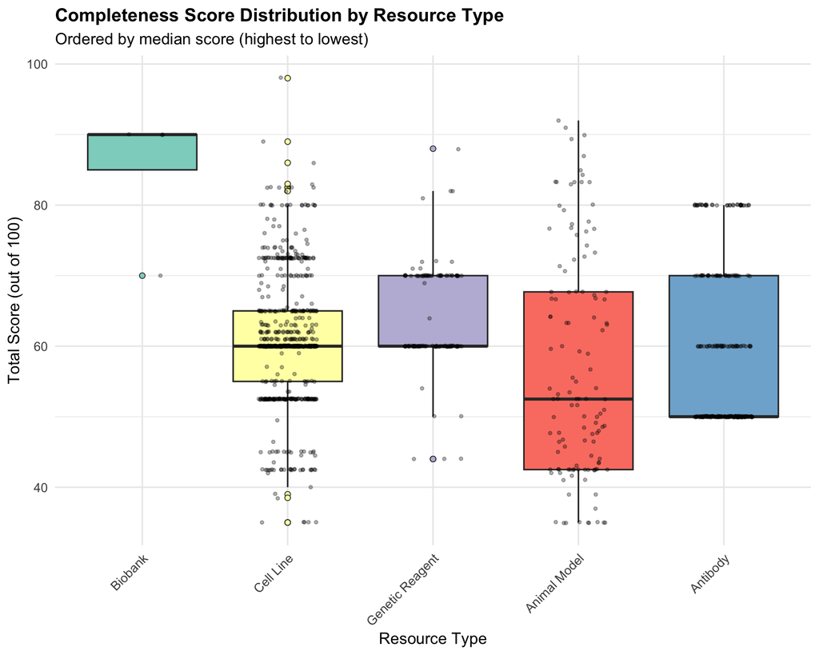

```r
# Order resource types by median score
type_order <- all_scores %>%
  group_by(resourceType) %>%
  summarize(median_score = median(total_score, na.rm = TRUE)) %>%
  arrange(desc(median_score)) %>%
  pull(resourceType)

all_scores$resourceType <- factor(all_scores$resourceType, levels = type_order)

# Boxplot by resource type
ggplot(all_scores, aes(x = resourceType, y = total_score, fill = resourceType)) +
  geom_boxplot(outlier.shape = 21, outlier.size = 2) +
  geom_jitter(width = 0.2, alpha = 0.3, size = 1) +
  scale_fill_brewer(palette = "Set3") +
  labs(title = "Completeness Score Distribution by Resource Type",
       subtitle = "Ordered by median score (highest to lowest)",
       x = "Resource Type",
       y = "Total Score (out of 100)") +
  theme_minimal(base_size = 14) +
  theme(plot.title = element_text(face = "bold", size = 16),
        axis.text.x = element_text(angle = 45, hjust = 1),
        legend.position = "none")
```

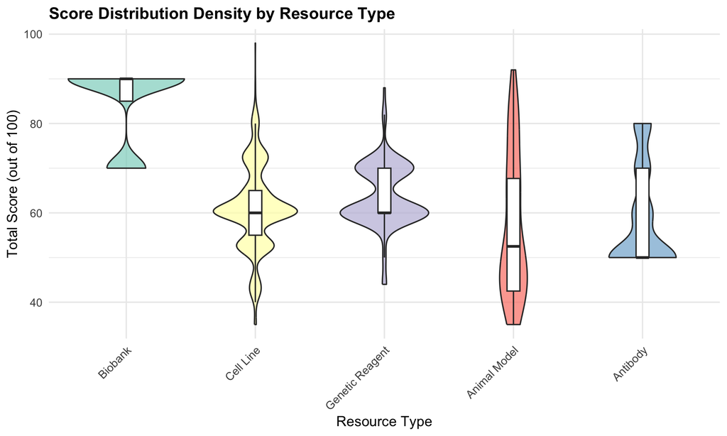

```r
# Violin plot by resource type
ggplot(all_scores, aes(x = resourceType, y = total_score, fill = resourceType)) +
  geom_violin(alpha = 0.7) +
  geom_boxplot(width = 0.1, fill = "white", outlier.shape = NA) +
  scale_fill_brewer(palette = "Set3") +
  labs(title = "Score Distribution Density by Resource Type",
       x = "Resource Type",
       y = "Total Score (out of 100)") +
  theme_minimal(base_size = 14) +
  theme(plot.title = element_text(face = "bold", size = 16),
        axis.text.x = element_text(angle = 45, hjust = 1),
        legend.position = "none")
```

## Completeness Category Distribution

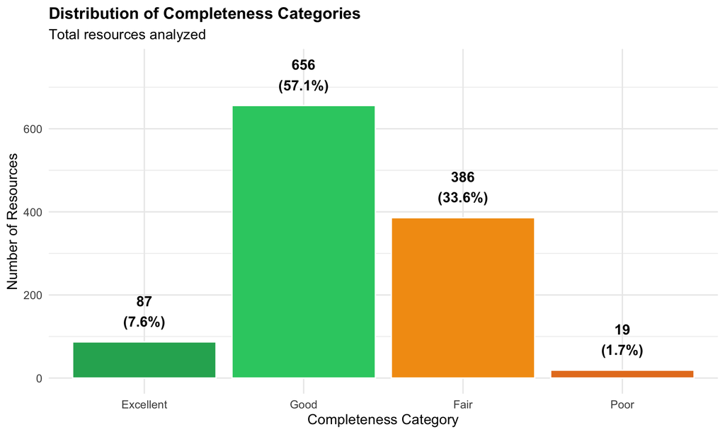

```r
# Count by completeness category
category_counts <- all_scores %>%
  group_by(completeness_category) %>%
  summarize(count = n()) %>%
  mutate(percentage = count / sum(count) * 100,
         completeness_category = factor(completeness_category,
                                       levels = c("Excellent", "Good", "Fair", "Poor", "Minimal")))

# Bar chart of completeness categories
ggplot(category_counts, aes(x = completeness_category, y = count, fill = completeness_category)) +
  geom_bar(stat = "identity", color = "white") +
  geom_text(aes(label = sprintf("%d\n(%.1f%%)", count, percentage)),
            vjust = -0.5, size = 5, fontface = "bold") +
  scale_fill_manual(values = c("Excellent" = "#27ae60", "Good" = "#2ecc71",
                               "Fair" = "#f39c12", "Poor" = "#e67e22",
                               "Minimal" = "#e74c3c")) +
  labs(title = "Distribution of Completeness Categories",
       subtitle = "Total resources analyzed",
       x = "Completeness Category",
       y = "Number of Resources") +
  theme_minimal(base_size = 14) +
  theme(plot.title = element_text(face = "bold", size = 16),
        legend.position = "none") +
  ylim(0, max(category_counts$count) * 1.15)
```

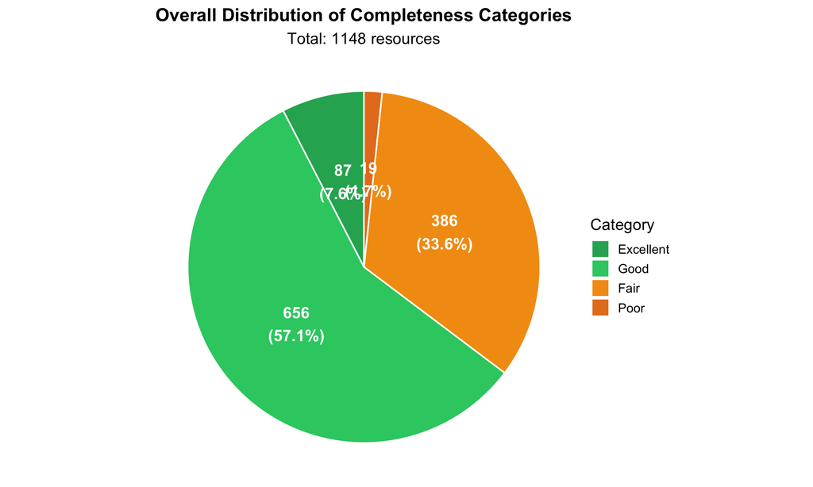

```r
# Overall pie chart of completeness categories
ggplot(category_counts, aes(x = "", y = count, fill = completeness_category)) +
  geom_bar(stat = "identity", width = 1, color = "white", size = 1.5) +
  coord_polar("y", start = 0) +
  scale_fill_manual(values = c("Excellent" = "#27ae60", "Good" = "#2ecc71",
                               "Fair" = "#f39c12", "Poor" = "#e67e22",
                               "Minimal" = "#e74c3c")) +
  geom_text(aes(label = sprintf("%d\n(%.1f%%)", count, percentage)),
            position = position_stack(vjust = 0.5),
            size = 5, fontface = "bold", color = "white") +
  labs(title = "Overall Distribution of Completeness Categories",
       subtitle = sprintf("Total: %d resources", sum(category_counts$count)),
       fill = "Category") +
  theme_void(base_size = 14) +
  theme(plot.title = element_text(face = "bold", size = 16, hjust = 0.5),
        plot.subtitle = element_text(hjust = 0.5),
        legend.position = "right")
```

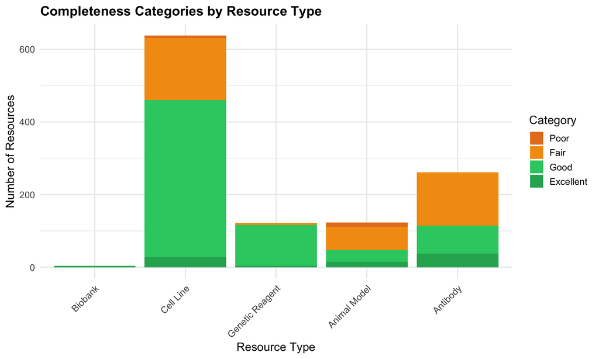

```r
# Stacked bar chart by resource type
category_by_type <- all_scores %>%
  group_by(resourceType, completeness_category) %>%
  summarize(count = n(), .groups = "drop") %>%
  mutate(completeness_category = factor(completeness_category,
                                       levels = c("Minimal", "Poor", "Fair", "Good", "Excellent")))

ggplot(category_by_type, aes(x = resourceType, y = count, fill = completeness_category)) +
  geom_bar(stat = "identity", position = "stack") +
  scale_fill_manual(values = c("Minimal" = "#e74c3c", "Poor" = "#e67e22",
                               "Fair" = "#f39c12", "Good" = "#2ecc71",
                               "Excellent" = "#27ae60")) +
  labs(title = "Completeness Categories by Resource Type",
       x = "Resource Type",
       y = "Number of Resources",
       fill = "Category") +
  theme_minimal(base_size = 14) +
  theme(plot.title = element_text(face = "bold", size = 16),
        axis.text.x = element_text(angle = 45, hjust = 1))
```

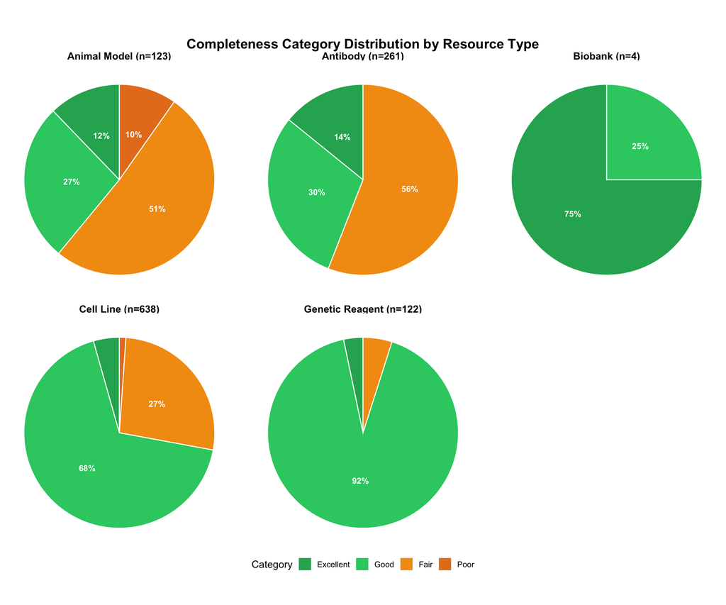

```r
# Pie charts by resource type
category_by_type_pct <- all_scores %>%
  group_by(resourceType, completeness_category) %>%
  summarize(count = n(), .groups = "drop") %>%
  group_by(resourceType) %>%
  mutate(
    total_resources = sum(count),
    percentage = count / sum(count) * 100,
    completeness_category = factor(completeness_category,
                                   levels = c("Excellent", "Good", "Fair", "Poor", "Minimal")),
    resourceType_label = sprintf("%s (n=%d)", resourceType, total_resources)
  ) %>%
  ungroup()

ggplot(category_by_type_pct, aes(x = "", y = percentage, fill = completeness_category)) +
  geom_bar(stat = "identity", width = 1, color = "white", size = 1) +
  coord_polar(theta = "y", start = 0) +
  scale_fill_manual(values = c("Excellent" = "#27ae60", "Good" = "#2ecc71",
                               "Fair" = "#f39c12", "Poor" = "#e67e22",
                               "Minimal" = "#e74c3c")) +
  geom_text(aes(label = ifelse(percentage >= 5, sprintf("%.0f%%", percentage), "")),
            position = position_stack(vjust = 0.5),
            size = 3.5, fontface = "bold", color = "white") +
  facet_wrap(~resourceType_label, ncol = 3) +
  labs(title = "Completeness Category Distribution by Resource Type",
       fill = "Category") +
  theme_void(base_size = 12) +
  theme(plot.title = element_text(face = "bold", size = 16, hjust = 0.5),
        legend.position = "bottom",
        strip.text = element_text(size = 12, face = "bold"))
```

## Missing Fields Analysis

```r
# Prepare missing fields data
missing_data <- all_scores %>%
  select(resourceType, missing_availability, missing_critical_info,
         missing_other_info, observation_status) %>%
  mutate(
    n_missing_availability = ifelse(is.na(missing_availability) | missing_availability == "",
                                     0,
                                     str_count(missing_availability, ";") + 1),
    n_missing_critical = ifelse(is.na(missing_critical_info) | missing_critical_info == "",
                                0,
                                str_count(missing_critical_info, ";") + 1),
    n_missing_other = ifelse(is.na(missing_other_info) | missing_other_info == "",
                            0,
                            str_count(missing_other_info, ";") + 1),
    has_observations = !grepl("No observations", observation_status, fixed = TRUE)
  )
```

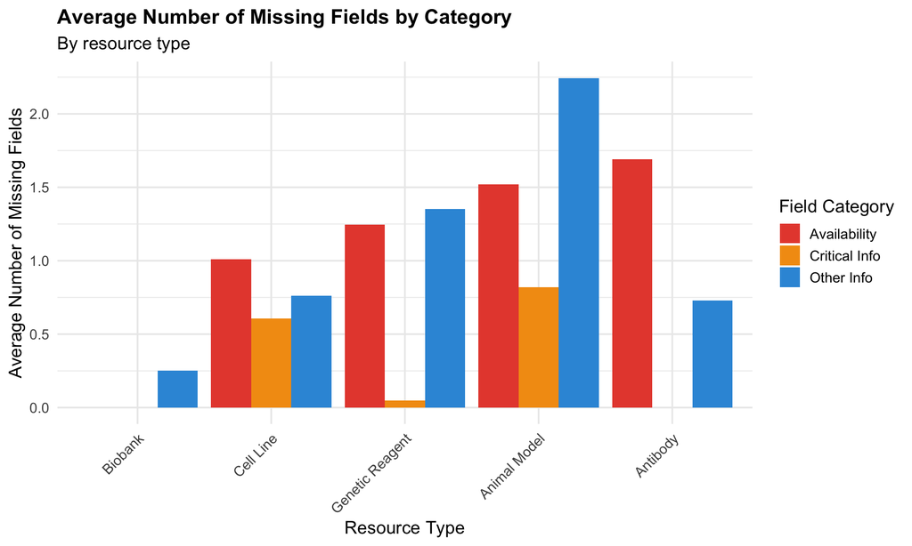

```r
# Summary of missing fields by category
missing_summary <- missing_data %>%
  group_by(resourceType) %>%
  summarize(
    avg_missing_availability = mean(n_missing_availability, na.rm = TRUE),
    avg_missing_critical = mean(n_missing_critical, na.rm = TRUE),
    avg_missing_other = mean(n_missing_other, na.rm = TRUE),
    pct_no_observations = sum(!has_observations) / n() * 100,
    .groups = "drop"
  ) %>%
  pivot_longer(cols = starts_with("avg_missing"),
               names_to = "category",
               values_to = "avg_missing") %>%
  mutate(category = case_when(
    category == "avg_missing_availability" ~ "Availability",
    category == "avg_missing_critical" ~ "Critical Info",
    category == "avg_missing_other" ~ "Other Info"
  ))

ggplot(missing_summary, aes(x = resourceType, y = avg_missing, fill = category)) +
  geom_bar(stat = "identity", position = "dodge") +
  scale_fill_manual(values = c("Availability" = "#e74c3c",
                               "Critical Info" = "#f39c12",
                               "Other Info" = "#3498db")) +
  labs(title = "Average Number of Missing Fields by Category",
       subtitle = "By resource type",
       x = "Resource Type",
       y = "Average Number of Missing Fields",
       fill = "Field Category") +
  theme_minimal(base_size = 14) +
  theme(plot.title = element_text(face = "bold", size = 16),
        axis.text.x = element_text(angle = 45, hjust = 1))
```

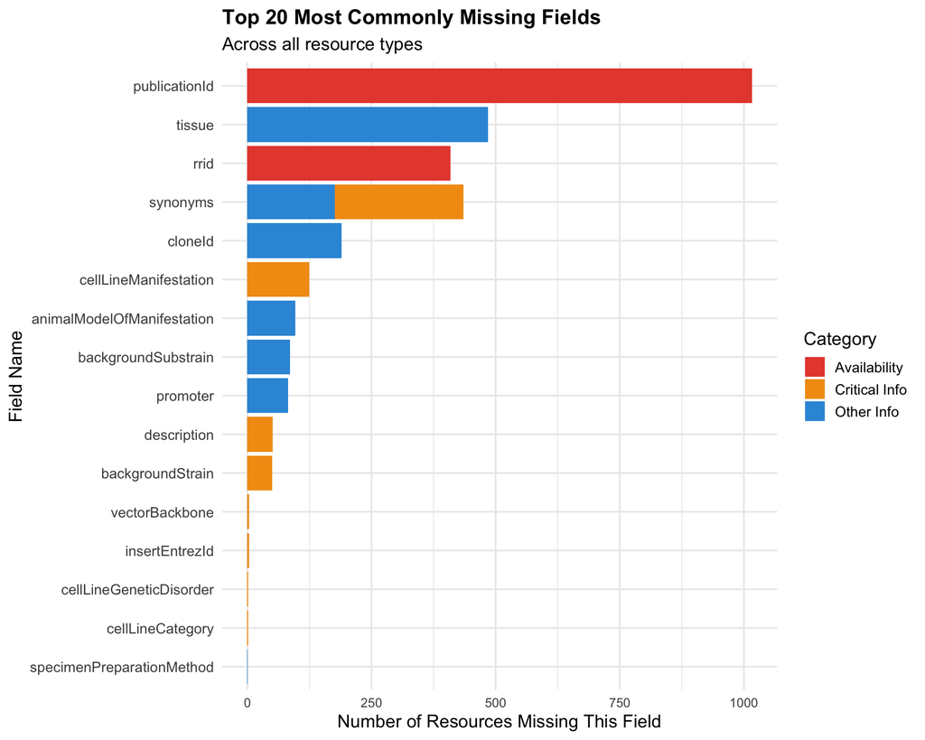

```r
# Find most common missing fields
all_missing_fields <- c()
all_missing_types <- c()
all_missing_categories <- c()

for (i in 1:nrow(all_scores)) {
  # Availability
  if (!is.na(all_scores$missing_availability[i]) && all_scores$missing_availability[i] != "") {
    fields <- strsplit(all_scores$missing_availability[i], "; ")[[1]]
    all_missing_fields <- c(all_missing_fields, fields)
    all_missing_types <- c(all_missing_types, rep(all_scores$resourceType[i], length(fields)))
    all_missing_categories <- c(all_missing_categories, rep("Availability", length(fields)))
  }

  # Critical Info
  if (!is.na(all_scores$missing_critical_info[i]) && all_scores$missing_critical_info[i] != "") {
    fields <- strsplit(all_scores$missing_critical_info[i], "; ")[[1]]
    all_missing_fields <- c(all_missing_fields, fields)
    all_missing_types <- c(all_missing_types, rep(all_scores$resourceType[i], length(fields)))
    all_missing_categories <- c(all_missing_categories, rep("Critical Info", length(fields)))
  }

  # Other Info
  if (!is.na(all_scores$missing_other_info[i]) && all_scores$missing_other_info[i] != "") {
    fields <- strsplit(all_scores$missing_other_info[i], "; ")[[1]]
    all_missing_fields <- c(all_missing_fields, fields)
    all_missing_types <- c(all_missing_types, rep(all_scores$resourceType[i], length(fields)))
    all_missing_categories <- c(all_missing_categories, rep("Other Info", length(fields)))
  }
}

missing_field_counts <- data.frame(
  field = all_missing_fields,
  resource_type = all_missing_types,
  category = all_missing_categories,
  stringsAsFactors = FALSE
) %>%
  group_by(field, category) %>%
  summarize(count = n(), .groups = "drop") %>%
  arrange(desc(count)) %>%
  head(20)

ggplot(missing_field_counts, aes(x = reorder(field, count), y = count, fill = category)) +
  geom_bar(stat = "identity") +
  scale_fill_manual(values = c("Availability" = "#e74c3c",
                               "Critical Info" = "#f39c12",
                               "Other Info" = "#3498db")) +
  labs(title = "Top 20 Most Commonly Missing Fields",
       subtitle = "Across all resource types",
       x = "Field Name",
       y = "Number of Resources Missing This Field",
       fill = "Category") +
  theme_minimal(base_size = 14) +
  theme(plot.title = element_text(face = "bold", size = 16),
        axis.text.x = element_text(size = 10)) +
  coord_flip()
```

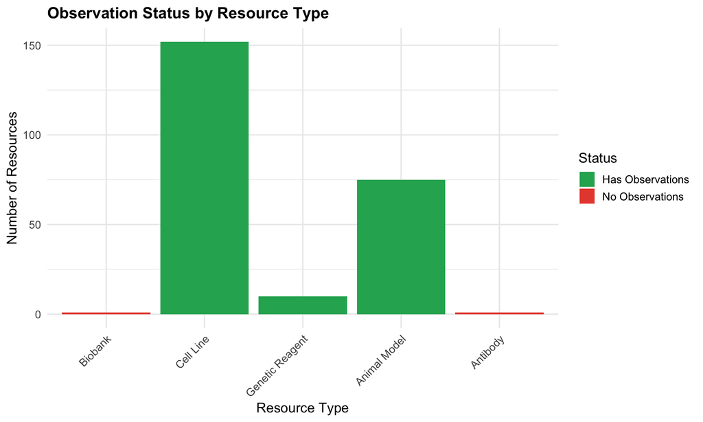

```r
# Observation status distribution
obs_status_summary <- missing_data %>%
  group_by(resourceType) %>%
  summarize(
    has_observations = sum(has_observations),
    no_observations = sum(!has_observations),
    .groups = "drop"
  ) %>%
  pivot_longer(cols = c(has_observations, no_observations),
               names_to = "status",
               values_to = "count") %>%
  mutate(status = ifelse(status == "has_observations",
                         "Has Observations",
                         "No Observations"))

ggplot(obs_status_summary, aes(x = resourceType, y = count, fill = status)) +
  geom_bar(stat = "identity", position = "stack") +
  scale_fill_manual(values = c("Has Observations" = "#27ae60",
                               "No Observations" = "#e74c3c")) +
  labs(title = "Observation Status by Resource Type",
       x = "Resource Type",
       y = "Number of Resources",
       fill = "Status") +
  theme_minimal(base_size = 14) +
  theme(plot.title = element_text(face = "bold", size = 16),
        axis.text.x = element_text(angle = 45, hjust = 1))
```

## Score Component Breakdown

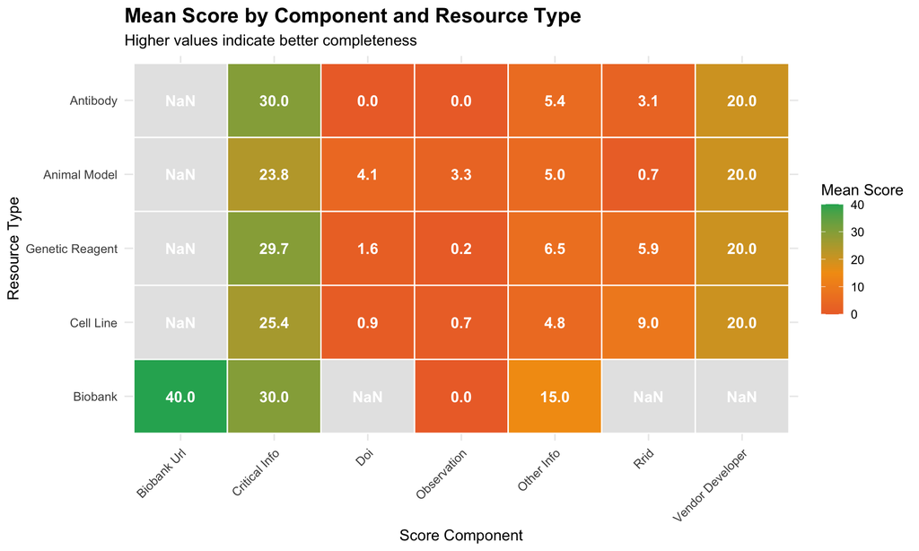

```r
# Prepare data for component breakdown
component_data <- all_scores %>%
  select(resourceType,
         biobank_url_score, vendor_developer_score, rrid_score, doi_score,
         critical_info_score, other_info_score, observation_score) %>%
  pivot_longer(cols = -resourceType,
               names_to = "component",
               values_to = "score") %>%
  mutate(component = gsub("_score", "", component),
         component = gsub("_", " ", component),
         component = tools::toTitleCase(component))

# Calculate mean scores by component and resource type
component_means <- component_data %>%
  group_by(resourceType, component) %>%
  summarize(mean_score = mean(score, na.rm = TRUE), .groups = "drop")

# Heatmap of mean component scores by resource type
ggplot(component_means, aes(x = component, y = resourceType, fill = mean_score)) +
  geom_tile(color = "white", size = 0.5) +
  geom_text(aes(label = sprintf("%.1f", mean_score)), color = "white", fontface = "bold") +
  scale_fill_gradient2(low = "#e74c3c", mid = "#f39c12", high = "#27ae60",
                      midpoint = 15, na.value = "grey90") +
  labs(title = "Mean Score by Component and Resource Type",
       subtitle = "Higher values indicate better completeness",
       x = "Score Component",
       y = "Resource Type",
       fill = "Mean Score") +
  theme_minimal(base_size = 12) +
  theme(plot.title = element_text(face = "bold", size = 16),
        axis.text.x = element_text(angle = 45, hjust = 1))
```

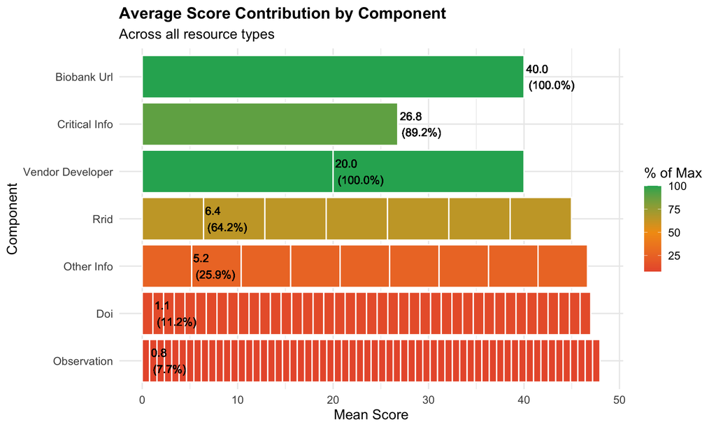

```r
# Overall component contribution
component_overall <- component_data %>%
  group_by(component) %>%
  summarize(mean_score = mean(score, na.rm = TRUE),
            max_possible = case_when(
              component %in% c("Biobank Url") ~ 40,
              component %in% c("Vendor Developer") ~ 20,
              component %in% c("Rrid", "Doi") ~ 10,
              component == "Critical Info" ~ 30,
              component == "Other Info" ~ 20,
              component == "Observation" ~ 10,
              TRUE ~ NA_real_
            )) %>%
  filter(!is.na(max_possible)) %>%
  mutate(percent_filled = (mean_score / max_possible) * 100)

# Bar chart of component contribution
ggplot(component_overall, aes(x = reorder(component, mean_score), y = mean_score)) +
  geom_bar(stat = "identity", aes(fill = percent_filled), color = "white") +
  geom_text(aes(label = sprintf("%.1f\n(%.1f%%)", mean_score, percent_filled)),
            hjust = -0.1, size = 4) +
  scale_fill_gradient2(low = "#e74c3c", mid = "#f39c12", high = "#27ae60",
                      midpoint = 50) +
  labs(title = "Average Score Contribution by Component",
       subtitle = "Across all resource types",
       x = "Component",
       y = "Mean Score",
       fill = "% of Max") +
  theme_minimal(base_size = 14) +
  theme(plot.title = element_text(face = "bold", size = 16)) +
  coord_flip() +
  ylim(0, max(component_overall$mean_score) * 1.2)
```

## Summary Statistics Tables

### Overall Statistics

```r
overall_stats <- data.frame(
  Metric = c("Total Resources", "Mean Score", "Median Score", "Std Dev",
             "Min Score", "Max Score", "Range"),
  Value = c(
    nrow(all_scores),
    round(mean(all_scores$total_score, na.rm = TRUE), 2),
    round(median(all_scores$total_score, na.rm = TRUE), 2),
    round(sd(all_scores$total_score, na.rm = TRUE), 2),
    round(min(all_scores$total_score, na.rm = TRUE), 2),
    round(max(all_scores$total_score, na.rm = TRUE), 2),
    round(max(all_scores$total_score, na.rm = TRUE) -
          min(all_scores$total_score, na.rm = TRUE), 2)
  )
)

kable(overall_stats, caption = "Overall Summary Statistics", align = c("l", "r"))
```

Overall Summary Statistics

| Metric | Value |
| --- | --- |
| Total Resources | 1148.00 |
| Mean Score | 60.32 |
| Median Score | 60.00 |
| Std Dev | 10.64 |
| Min Score | 35.00 |
| Max Score | 98.00 |
| Range | 63.00 |

### Statistics by Resource Type

```r
type_stats <- summary_by_type %>%
  select(resourceType, count, mean_score, median_score, sd_score, min_score, max_score) %>%
  arrange(desc(mean_score)) %>%
  mutate(across(where(is.numeric), ~round(., 2)))

colnames(type_stats) <- c("Resource Type", "Count", "Mean", "Median", "Std Dev", "Min", "Max")

datatable(type_stats,
          caption = "Summary Statistics by Resource Type",
          options = list(pageLength = 15,
                        autoWidth = TRUE),
          rownames = FALSE) %>%
  formatStyle(columns = "Mean",
              background = styleColorBar(type_stats$Mean, '#3498db'),
              backgroundSize = '100% 90%',
              backgroundRepeat = 'no-repeat',
              backgroundPosition = 'center')
```

| Resource Type | Count | Mean | Median | Std Dev | Min | Max |
| --- | --- | --- | --- | --- | --- | --- |
| Biobank | 4 | 85 | 90 | 10 | 70 | 90 |
| Genetic Reagent | 122 | 63.93 | 60 | 7.03 | 44 | 88 |
| Cell Line | 638 | 60.85 | 60 | 9.22 | 35 | 98 |
| Antibody | 261 | 58.54 | 50 | 11.14 | 50 | 80 |
| Animal Model | 123 | 56.94 | 52.5 | 15.87 | 35 | 92 |

### Top 20 Most Complete Resources

```r
top_resources <- all_scores %>%
  arrange(desc(total_score)) %>%
  select(resourceName, resourceType, rrid, total_score, completeness_category) %>%
  head(20) %>%
  mutate(total_score = round(total_score, 1))

colnames(top_resources) <- c("Resource Name", "Type", "RRID", "Score", "Category")

datatable(top_resources,
          caption = "Top 20 Most Complete Resources",
          options = list(pageLength = 20),
          rownames = FALSE) %>%
  formatStyle(columns = "Category",
              backgroundColor = styleEqual(
                c("Excellent", "Good", "Fair", "Poor", "Minimal"),
                c("#27ae60", "#2ecc71", "#f39c12", "#e67e22", "#e74c3c")
              ),
              color = "white",
              fontWeight = "bold")
```

| Resource Name | Type | RRID | Score | Category |
| --- | --- | --- | --- | --- |
| SK-N-AS | Cell Line | rrid:CVCL_1700 | 98 | Excellent |
| B6.129S6-Nf1tm1Fcr/J | Animal Model | rrid:IMSR_JAX:002646 | 92 | Excellent |
| B6.129(Cg)-Nf1tm1Par/J | Animal Model | rrid:IMSR_JAX:017640 | 91 | Excellent |
| Nf14F/4F;CAGGCre-ERTM | Animal Model |  | 90 | Excellent |
| The Johns Hopkins NF1 Biospecimen Repository | Biobank |  | 90 | Excellent |
| CTF Biobank | Biobank |  | 90 | Excellent |
| Coriell Institute for Medical Research Biobank | Biobank |  | 90 | Excellent |
| B6;129S2-Trp53tm1Tyj Nf1tm1Tyj/J | Animal Model | rrid:IMSR_JAX:008191 | 89.3 | Excellent |
| GI-ME-N | Cell Line | rrid:CVCL_1232 | 89 | Excellent |
| pAMP-CY1_NF1 T1 (+minintr, KDR) | Genetic Reagent | rrid:Addgene_119200 | 88 | Excellent |

[output cut: 10 more lines]

### Resources Needing Improvement (Score < 40)

```r
incomplete_resources <- all_scores %>%
  filter(total_score < 40) %>%
  arrange(total_score) %>%
  select(resourceName, resourceType, total_score, completeness_category) %>%
  mutate(total_score = round(total_score, 1))

if (nrow(incomplete_resources) > 0) {
  colnames(incomplete_resources) <- c("Resource Name", "Type", "Score", "Category")

  datatable(incomplete_resources,
            caption = sprintf("Resources Needing Improvement (N = %d)",
                            nrow(incomplete_resources)),
            options = list(pageLength = 15),
            rownames = FALSE) %>%
    formatStyle(columns = "Category",
                backgroundColor = styleEqual(
                  c("Excellent", "Good", "Fair", "Poor", "Minimal"),
                  c("#27ae60", "#2ecc71", "#f39c12", "#e67e22", "#e74c3c")
                ),
                color = "white",
                fontWeight = "bold")
} else {
  cat("No resources with scores below 40. Excellent!")
}
```

| Resource Name | Type | Score | Category |
| --- | --- | --- | --- |
| Dh5 alpha | Cell Line | 35 | Poor |
| ELK-TAD Luciferase Reporter HEK293 Stable | Cell Line | 35 | Poor |
| c.1149C &gt; A NF1-mutant hiPSCs | Cell Line | 35 | Poor |
| c.3431-32_dupGT NF1-mutant hiPSCs | Cell Line | 35 | Poor |
| U87-NF1-419 | Cell Line | 35 | Poor |
| Krox20;Nf1flox/- | Animal Model | 35 | Poor |
| MPNST-Nf1-001 | Animal Model | 35 | Poor |
| MPNST-Nf1-002 | Animal Model | 35 | Poor |
| MPNST-SP-001 | Animal Model | 35 | Poor |
| MPSNT-SP-002 | Animal Model | 35 | Poor |

[output cut: 9 more lines]

## Recommendations

Based on the analysis above, here are key recommendations for improving resource completeness:

1. **Focus on Low-Scoring Components**: Identify which score components (availability, critical info, other info, observations) have the lowest average scores across resource types and prioritize filling those fields.
2. **Resource Type Priorities**: Target resource types with lower median scores for systematic improvement efforts.
3. **Observation Documentation**: Encourage researchers to publish observations with DOIs, as these contribute more points (3 vs 1) to the completeness score.
4. **RRID Registration**: Ensure all resources have registered RRIDs to improve findability and citation.
5. **Vendor/Developer Information**: Complete vendor or developer information for resources to improve availability scores.